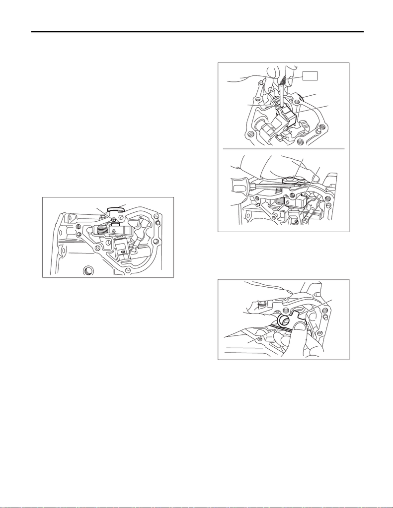

6MT(TY75)-71

Shift Link Assembly

MANUAL TRANSMISSION AND DIFFERENTIAL

14.Shift Link Assembly

A: REMOVAL

1) Remove the manual transmission assembly

from the vehicle. <Ref. to 6MT(TY75)-25, REMOV-

AL, Manual Transmission Assembly.>

2) Remove the back-up light switch and the neutral

position switch. <Ref. to 6MT(TY75)-45, REMOV-

AL, Switches and Harness.>

3) Remove the transfer case together with the ex-

tension case assembly. <Ref. to 6MT(TY75)-51,

REMOVAL, Transfer Case and Extension Case

Assembly.>

4) Remove the extension case assembly. <Ref. to

6MT(TY75)-51, REMOVAL, Transfer Case and Ex-

tension Case Assembly.>

5) Remove the center differential and transfer driv-

en gear as a unit. <Ref. to 6MT(TY75)-65, REMOV-

AL, Transfer Driven Gear.>

7) Use the ST to remove the straight pin, and re-

move the selector lever COMPL.

ST 398791700 SPRING PIN REMOVER 2

8) Remove the selector arm No. 2.

(A) Selector lever COMPL

(B) Straight pin

MT-01901

(A)

(B)

(A) Selector lever COMPL

(B) Selector arm No. 2

(C) Straight pin

(A) Selector arm No. 2

(B) Neutral set spring

MT-01902

(A)

(B)

(A)

(C)

(B)

ST

MT-01903

(A)

(B)

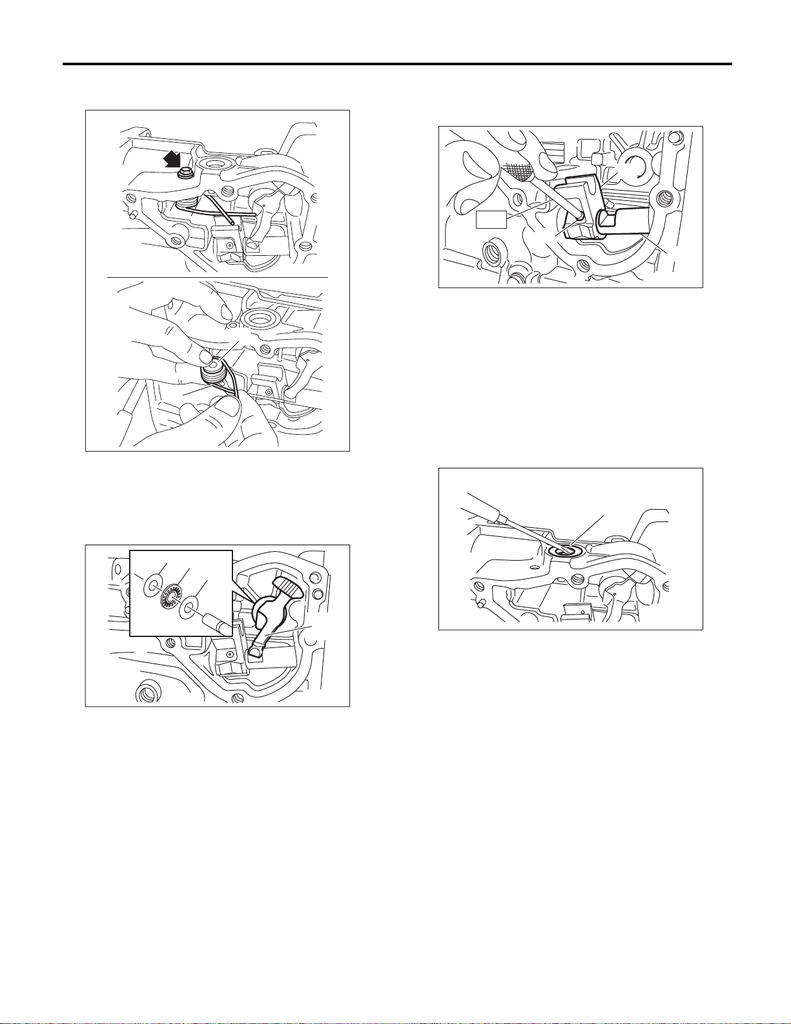

6MT(TY75)-72

Shift Link Assembly

MANUAL TRANSMISSION AND DIFFERENTIAL

9) Remove the bolts and remove the shifter arm

collar and neutral set spring.

10) Remove the shifter arm No. 2, washers and

thrust bearing.

11) Use the ST to remove the straight pin, and re-

move the shifter arm and selector arm.

ST 398791700 SPRING PIN REMOVER 2

12) Remove the oil seal using a screwdriver

wrapped with tape, etc.

NOTE:

The illustration shows the oil seal of selector lever

COMPL. Perform the same procedures for remov-

ing the shifter arm No. 2.

(A) Shifter arm collar

(B) Neutral set spring

(A) Shifter arm No. 2

(B) Washer

(C) Thrust bearing

MT-03078

(B)

(A)

MT-01905

(A)

(B)

(B)

(C)

(A) Shifter arm

(B) Selector arm

(C) Straight pin

(A) Oil seal

MT-01906

ST

(B)

(C)

(A)

MT-02408

(A)

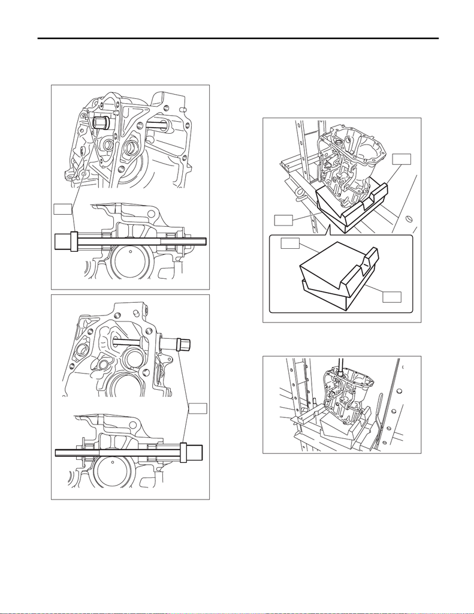

6MT(TY75)-73

Shift Link Assembly

MANUAL TRANSMISSION AND DIFFERENTIAL

13) Remove the needle bearing by using a tube

with the diameter of 20 mm (0.79 in) or 21 mm (0.83

in) and the ST.

ST 18763AA000 COMPRESSOR SHAFT

14) Set ST1, ST2 and transfer case to a press.

NOTE:

• Set the ST2 under ST1.

• Set the transfer case so that the hole for shifter

arm is positioned vertically.

ST1 498267300 CYLINDER HEAD TABLE

ST2 498267200 CYLINDER HEAD TABLE

15) Remove the roller bearing by using a round bar

with the diameter of 22 mm (0.87 in) or 23 mm (0.91

in).

16) Flip over the transfer case, and set an iron plate

between transfer case and ST.

NOTE:

• Insert the iron plate which is thicker than the ex-

posed length of the transfer case knock pin be-

tween the ST and transfer case.

• Set the iron plate so that the transfer case knock

pin does not ride on the iron plate.

MT-02261

ST

MT-02832

ST

MT-02263

ST2

ST1

ST1

ST2

MT-02264

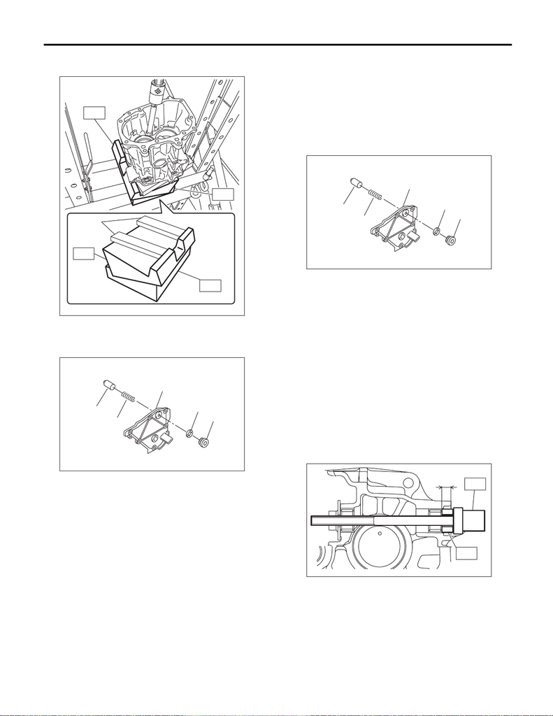

6MT(TY75)-74

Shift Link Assembly

MANUAL TRANSMISSION AND DIFFERENTIAL

17) Remove the roller bearing by using a tube with

the diameter of 22 mm (0.87 in) or 23 mm (0.91 in).

18) Remove the plunger and the check ball spring.

B: INSTALLATION

1) Clean the mating surface of the transmission

cover and transfer case.

2) Install the plunger and the check ball spring.

NOTE:

Use new seal rings.

Tightening torque:

25 N·m (2.5 kgf-m, 18.4 ft-lb)

3) Using the ST, install the needle bearing.

NOTE:

• Use a new needle bearing.

• If the press-fit depth exceeds the service limit, re-

place with a new needle bearing.

ST1 18763AA000 COMPRESSOR SHAFT

ST2 498277200 STOPPER SET

Press-fit depth of needle bearing:

A: 8.5

±

0.2 mm (0.33

±

0.01 in) from the end of

transfer case

(A) Iron plate

(A) Plunger

(B) Checking ball spring

(C) Transmission cover

(D) Seal ring

(E) Seal bolt

MT-02269

(A)

ST2

ST1

ST1

ST2

MT-01922

(C)

(B)

(E)

(A)

(D)

(A) Plunger

(B) Checking ball spring

(C) Transmission cover

(D) Seal ring

(E) Seal bolt

MT-01922

(C)

(B)

(E)

(A)

(D)

MT-02265

ST1

ST2

A

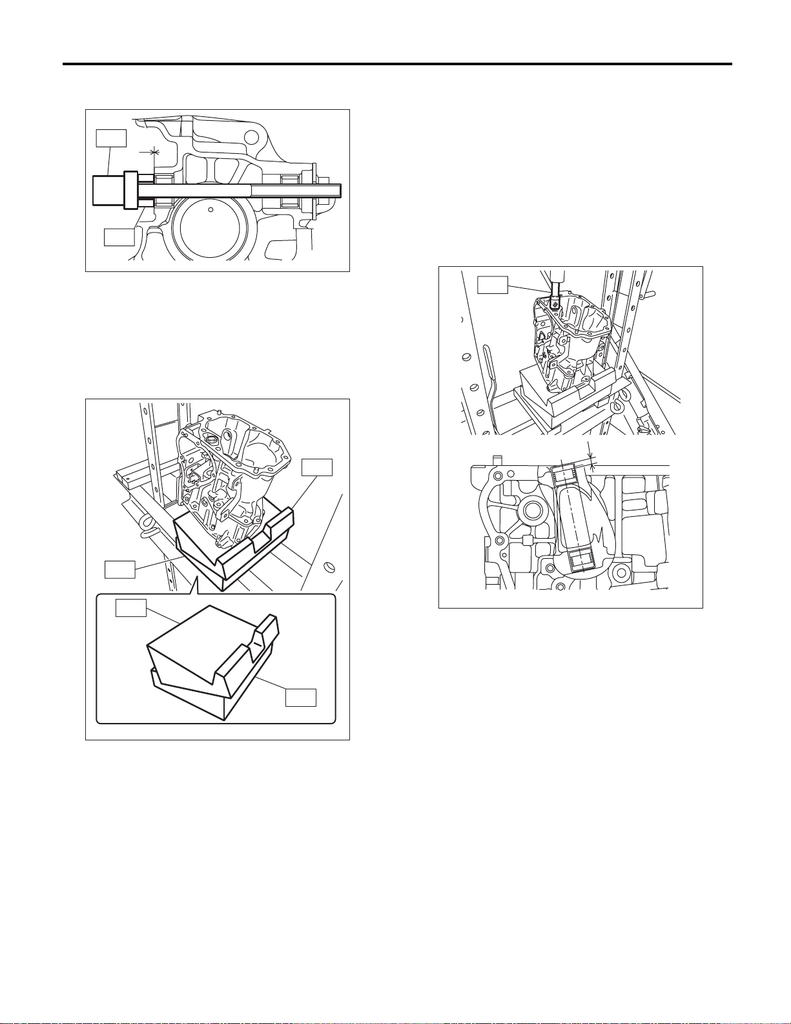

6MT(TY75)-75

Shift Link Assembly

MANUAL TRANSMISSION AND DIFFERENTIAL

B: 0.2

±

0.2 mm (0.01

±

0.01 in) from the end of

transfer case

4) Set ST1, ST2 and transfer case to a press.

NOTE:

• Set the ST2 under ST1.

• Set the transfer case so that the hole for shifter

arm is positioned vertically.

ST1 498267300 CYLINDER HEAD TABLE

ST2 498267200 CYLINDER HEAD TABLE

5) Using the ST, install the roller bearing.

NOTE:

• Use a new roller bearing.

• Gradually perform the press-fit operation while

measuring the press-fit depth.

• If the press-fit depth exceeds the service limit, re-

place with a new bearing.

ST 899864100 REMOVER

Press-fit depth of roller bearing:

A: 5.1

±

0.2 mm (0.20

±

0.01 in) from the finished

surface of transfer case

6) Flip over the transfer case, and set an iron plate

between transfer case and ST.

NOTE:

• Insert the iron plate which is thicker than the ex-

posed length of the transfer case knock pin be-

tween the ST and transfer case.

• Set the parts while taking care that the transfer

case knock pin and the roller bearing do not ride

over the iron plate.

MT-02266

ST2

ST1

B

MT-02263

ST2

ST1

ST1

ST2

MT-02463

A

ST

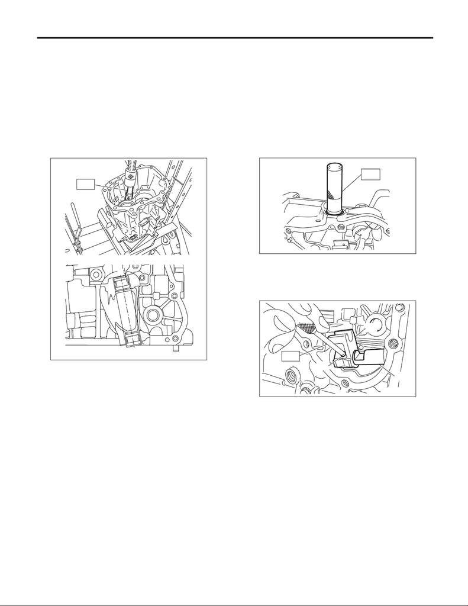

6MT(TY75)-76

Shift Link Assembly

MANUAL TRANSMISSION AND DIFFERENTIAL

7) Using the ST, install the roller bearing.

NOTE:

• Use a new roller bearing.

• Gradually perform the press-fit operation while

measuring the press-fit depth.

• If the press-fit depth exceeds the service limit, re-

place with a new bearing.

ST 899864100 REMOVER

Press-fit depth of roller bearing:

A: 0

±

0.2 mm (0

±

0.01 in) from the end of trans-

fer case

8) Using the ST, install the oil seal.

NOTE:

• Use a new oil seal.

• The illustration shows the oil seal of selector le-

ver COMPL. Perform the same procedures for in-

stalling the oil seal of shifter arm No. 2.

• Apply transmission gear oil to the oil seal lips.

ST 18657AA000 INSTALLER

Press-fit depth of oil seal:

1

±

0.2 mm (0.04

±

0.01 in) from the end of trans-

fer case

9) Insert the shifter arm and fix with a straight pin.

NOTE:

Use a new straight pin.

ST 398791700 SPRING PIN REMOVER 2

MT-02464

A

ST

(A) Shifter arm

(B) Selector arm

(C) Straight pin

MT-02465

ST

MT-01906

ST

(B)

(C)

(A)

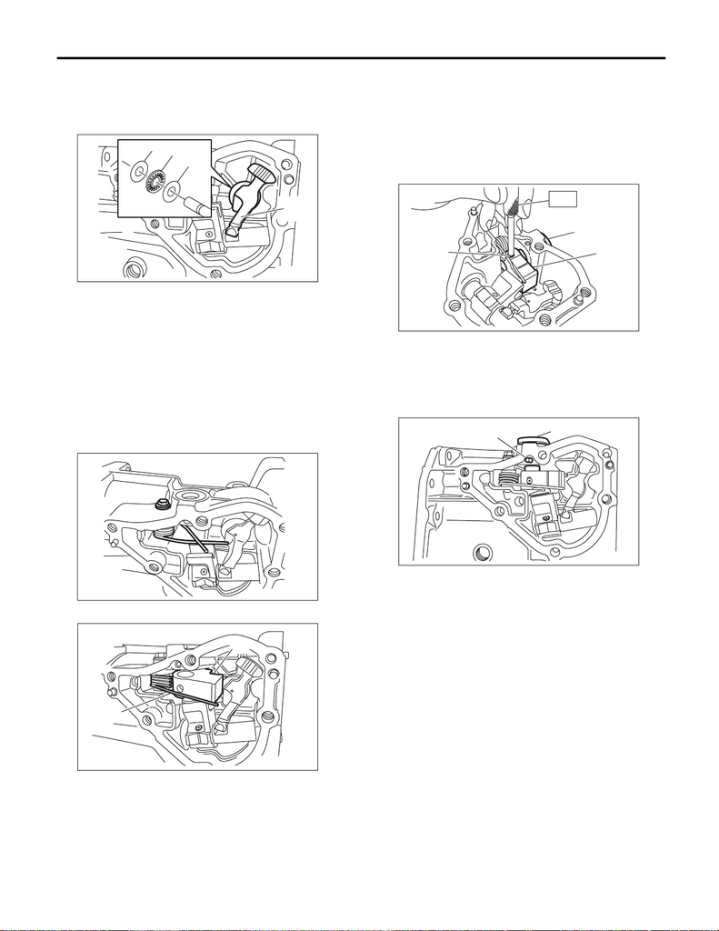

6MT(TY75)-77

Shift Link Assembly

MANUAL TRANSMISSION AND DIFFERENTIAL

10) Install the shifter arm No. 2, washers and thrust

bearing.

CAUTION:

Be careful not to damage the oil seal.

11) Install the shifter arm collar and neutral set

spring.

NOTE:

Use a new gasket.

Tightening torque:

6.4 N·m (0.7 kgf-m, 4.7 ft-lb)

12) Install the selector arm No. 2.

13) Insert the selector lever COMPL and fix with a

straight pin.

CAUTION:

Be careful not to damage the oil seal.

NOTE:

Use a new straight pin.

ST 398791700 SPRING PIN REMOVER 2

14) Insert a new straight pin.

15) Install the center differential and transfer driven

gear as a unit.

16) Install the extension case assembly to the

transfer case. <Ref. to 6MT(TY75)-53, INSTALLA-

TION, Transfer Case and Extension Case Assem-

bly.>

17) Install the transfer case and the extension case

assembly. <Ref. to 6MT(TY75)-53, INSTALLA-

TION, Transfer Case and Extension Case Assem-

bly.>

(A) Shifter arm No. 2

(B) Washer

(C) Thrust bearing

(A) Selector arm No. 2

(B) Neutral set spring

MT-01905

(A)

(B)

(B)

(C)

MT-01907

MT-01908

(A)

(B)

(A) Selector lever COMPL

(B) Selector arm No. 2

(C) Straight pin

(A) Selector lever COMPL

(B) Straight pin

MT-01909

(A)

(C)

(B)

ST

MT-01901

(A)

(B)

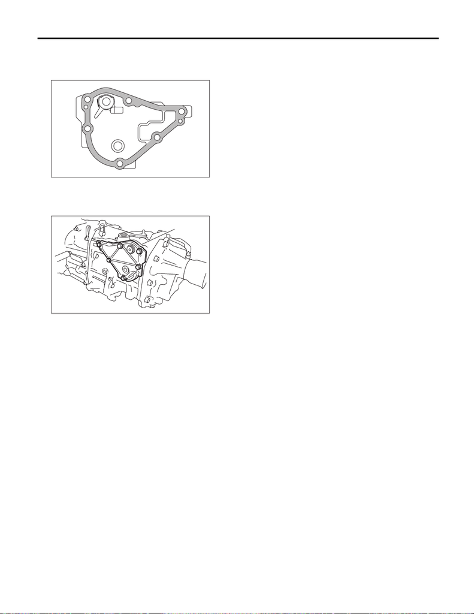

6MT(TY75)-78

Shift Link Assembly

MANUAL TRANSMISSION AND DIFFERENTIAL

18) Apply liquid gasket seamlessly.

Liquid gasket:

THREE BOND 1215B or equivalent

19) Install the transmission cover.

Tightening torque:

25 N·m (2.5 kgf-m, 18.4 ft-lb)

20) Install the back-up light switch and the neutral

position switch. <Ref. to 6MT(TY75)-46, INSTAL-

LATION, Switches and Harness.>

21) Install the manual transmission assembly to the

vehicle. <Ref. to 6MT(TY75)-30, INSTALLATION,

Manual Transmission Assembly.>

(A) Transmission cover

MT-02459

MT-02981

(A)